# Multi-Week Assignment#2 Part 2 - Classification and Summary Report

## MSCA 37014 Python for Analytics

### Assignment#2 Supervised Learning Classification

### Exploratory Data Analysis, Data Preprocessing, Classification Model

### Due Date: 3/20/2020

Please submit your assignment solutions in **PDF** or **HTML** file; **Submitted Jupyter Notebook will not be graded**

### BankMarketingAdditional Data Description

# bank client data:

`age` :(numeric)

`job` : type of job (categorical: 'admin.','bluecollar','entrepreneur','housemaid','management','retired','self-employed','services','student','technician','unemployed','unknown')

`marital` : marital status (categorical: 'divorced','married','single','unknown'; note: 'divorced' means divorced or widowed)

`education` (categorical: 'basic.4y','basic.6y','basic.9y','high.school','illiterate','professional.course','university.degree','unknown')

`default` : has credit in default? (categorical: 'no','yes','unknown')

`housing`: has housing loan? (categorical: 'no','yes','unknown')

`loan` : has personal loan? (categorical: 'no','yes','unknown')

# related with the last contact of the current campaign:

`contact` : contact communication type (categorical: 'cellular','telephone')

`month` : last contact month of year (categorical: 'jan', 'feb', 'mar', ..., 'nov', 'dec')

`day_of_week` : last contact day of the week (categorical: 'mon','tue','wed','thu','fri')

`duration` : last contact duration, in seconds (numeric). Important note: this attribute highly affects the output target (e.g., if duration=0 then y='no'). Yet, the duration is not known before a call is performed. Also, after the end of the call y is obviously known. Thus, this input should only be included for benchmark purposes and should be discarded if the intention is to have a realistic predictive model.

# other attributes:

`campaign` : number of contacts performed during this campaign and for this client (numeric, includes last contact)

`pdays` : number of days that passed by after the client was last contacted from a previous campaign (numeric; 999 means client was not previously contacted)

`previous` : number of contacts performed before this campaign and for this client (numeric)

`poutcome` : outcome of the previous marketing campaign (categorical: 'failure','nonexistent','success')

# social and economic context attributes

`emp.var.rate` : employment variation rate - quarterly indicator (numeric)

`cons.price.idx` : consumer price index - monthly indicator (numeric)

`cons.conf.idx` : consumer confidence index - monthly indicator (numeric)

`euribor3m` : euribor 3 month rate - daily indicator (numeric)

`nr.employed` : number of employees - quarterly indicator (numeric)

## Part 1 - Exploratory Data Analysis and Data Visualization

### 1. Import Libraries and oad the data into the pandas data frame

```python
# Student's Answer:
%matplotlib inline
import numpy as np
import matplotlib.pyplot as plt
import pandas as pd
import seaborn as sns


# Import Scikit-Learn functions and classifiers
from sklearn.pipeline import make_pipeline
from sklearn.preprocessing import StandardScaler
from sklearn.linear_model import LogisticRegression
from sklearn.ensemble import RandomForestClassifier
from sklearn.tree import DecisionTreeClassifier
from sklearn.svm import SVC
from sklearn.neighbors import KNeighborsClassifier

from sklearn.model_selection import train_test_split
from sklearn.model_selection import GridSearchCV
from sklearn.metrics import classification_report, confusion_matrix, accuracy_score, roc_auc_score
```

### 2. Review data dimension and data type for each feature

```python
# Student's Answer:
dataset = pd.read_csv('BankMarketingAdditional-1.csv', sep=';')
dataset.info()
```

```
<class 'pandas.core.frame.DataFrame'>
RangeIndex: 41188 entries, 0 to 41187
Data columns (total 21 columns):
 #   Column          Non-Null Count  Dtype
---  ------          --------------  -----
 0   age             41188 non-null  int64
 1   job             41188 non-null  object
 2   marital         41188 non-null  object
 3   education       41188 non-null  object
 4   default         41188 non-null  object
 5   housing         41188 non-null  object
 6   loan            41188 non-null  object
 7   contact         41188 non-null  object
 8   month           41188 non-null  object
 9   day_of_week     41188 non-null  object
 10  duration        41188 non-null  int64
 11  campaign        41188 non-null  int64
 12  pdays           41188 non-null  int64
 13  previous        41188 non-null  int64
 14  poutcome        41188 non-null  object
 15  emp.var.rate    41188 non-null  float64
 16  cons.price.idx  41188 non-null  float64
 17  cons.conf.idx   41188 non-null  float64
 18  euribor3m       41188 non-null  float64
 19  nr.employed     41188 non-null  float64
 20  y               41188 non-null  object
dtypes: float64(5), int64(5), object(11)
memory usage: 6.6+ MB
```

```python
dataset
```

|  | age | job | marital | education | default | housing | loan | contact | month | day_of_week | ... | campaign | pdays | previous | poutcome | emp.var.rate | cons.price.idx | cons.conf.idx | euribor3m | nr.employed | y |
| --- | --- | --- | --- | --- | --- | --- | --- | --- | --- | --- | --- | --- | --- | --- | --- | --- | --- | --- | --- | --- | --- |
| 0 | 56 | housemaid | married | basic.4y | no | no | no | telephone | may | mon | ... | 1 | 999 | 0 | nonexistent | 1.1 | 93.994 | -36.4 | 4.857 | 5191.0 | no |
| 1 | 57 | services | married | high.school | unknown | no | no | telephone | may | mon | ... | 1 | 999 | 0 | nonexistent | 1.1 | 93.994 | -36.4 | 4.857 | 5191.0 | no |
| 2 | 37 | services | married | high.school | no | yes | no | telephone | may | mon | ... | 1 | 999 | 0 | nonexistent | 1.1 | 93.994 | -36.4 | 4.857 | 5191.0 | no |
| 3 | 40 | admin. | married | basic.6y | no | no | no | telephone | may | mon | ... | 1 | 999 | 0 | nonexistent | 1.1 | 93.994 | -36.4 | 4.857 | 5191.0 | no |
| 4 | 56 | services | married | high.school | no | no | yes | telephone | may | mon | ... | 1 | 999 | 0 | nonexistent | 1.1 | 93.994 | -36.4 | 4.857 | 5191.0 | no |
| ... | ... | ... | ... | ... | ... | ... | ... | ... | ... | ... | ... | ... | ... | ... | ... | ... | ... | ... | ... | ... | ... |
| 41183 | 73 | retired | married | professional.course | no | yes | no | cellular | nov | fri | ... | 1 | 999 | 0 | nonexistent | -1.1 | 94.767 | -50.8 | 1.028 | 4963.6 | yes |
| 41184 | 46 | blue-collar | married | professional.course | no | no | no | cellular | nov | fri | ... | 1 | 999 | 0 | nonexistent | -1.1 | 94.767 | -50.8 | 1.028 | 4963.6 | no |
| 41185 | 56 | retired | married | university.degree | no | yes | no | cellular | nov | fri | ... | 2 | 999 | 0 | nonexistent | -1.1 | 94.767 | -50.8 | 1.028 | 4963.6 | no |
| 41186 | 44 | technician | married | professional.course | no | no | no | cellular | nov | fri | ... | 1 | 999 | 0 | nonexistent | -1.1 | 94.767 | -50.8 | 1.028 | 4963.6 | yes |
| 41187 | 74 | retired | married | professional.course | no | yes | no | cellular | nov | fri | ... | 3 | 999 | 1 | failure | -1.1 | 94.767 | -50.8 | 1.028 | 4963.6 | no |

41188 rows × 21 columns

### 3. Identify the unique number of values of each feature in the dataset

```python
# Student's Answer:
dataset['age'].value_counts()
```

```
31    1947
32    1846
33    1833
36    1780
35    1759
      ...
89       2
91       2
87       1
94       1
95       1
Name: age, Length: 78, dtype: int64
```

```python
dataset['age'].unique()
```

```
array([56, 57, 37, 40, 45, 59, 41, 24, 25, 29, 35, 54, 46, 50, 39, 30, 55,
       49, 34, 52, 58, 32, 38, 44, 42, 60, 53, 47, 51, 48, 33, 31, 43, 36,
       28, 27, 26, 22, 23, 20, 21, 61, 19, 18, 70, 66, 76, 67, 73, 88, 95,
       77, 68, 75, 63, 80, 62, 65, 72, 82, 64, 71, 69, 78, 85, 79, 83, 81,
       74, 17, 87, 91, 86, 98, 94, 84, 92, 89])
```

```python
dataset['job'].value_counts()
```

```
admin.           10422
blue-collar       9254
technician        6743
services          3969
management        2924
retired           1720
entrepreneur      1456
self-employed     1421
housemaid         1060
unemployed        1014
student            875
unknown            330
Name: job, dtype: int64
```

```python
dataset['job'].unique()
```

```
array(['housemaid', 'services', 'admin.', 'blue-collar', 'technician',
       'retired', 'management', 'unemployed', 'self-employed', 'unknown',
       'entrepreneur', 'student'], dtype=object)
```

```python
dataset['marital'].value_counts()
```

```
married     24928
single      11568
divorced     4612
unknown        80
Name: marital, dtype: int64
```

```python
dataset['marital'].unique()
```

```
array(['married', 'single', 'divorced', 'unknown'], dtype=object)
```

```python
dataset['housing'].value_counts()
```

```
yes        21576
no         18622
unknown      990
Name: housing, dtype: int64
```

```python
dataset['housing'].unique()
```

```
array(['no', 'yes', 'unknown'], dtype=object)
```

```python
dataset['loan'].value_counts()
```

```
no         33950
yes         6248
unknown      990
Name: loan, dtype: int64
```

```python
dataset['loan'].unique()
```

```
array(['no', 'yes', 'unknown'], dtype=object)
```

```python
dataset['education'].value_counts()
```

```
university.degree      12168
high.school             9515
basic.9y                6045
professional.course     5243
basic.4y                4176
basic.6y                2292
unknown                 1731
illiterate                18
Name: education, dtype: int64
```

```python
dataset['education'].unique()
```

```
array(['basic.4y', 'high.school', 'basic.6y', 'basic.9y',
       'professional.course', 'unknown', 'university.degree',
       'illiterate'], dtype=object)
```

```python
dataset['loan'].value_counts()
```

```
no         33950
yes         6248
unknown      990
Name: loan, dtype: int64
```

```python
dataset['loan'].unique()
```

```
array(['no', 'yes', 'unknown'], dtype=object)
```

```python
dataset['contact'].value_counts()
```

```
cellular     26144
telephone    15044
Name: contact, dtype: int64
```

```python
dataset['contact'].unique()
```

```
array(['telephone', 'cellular'], dtype=object)
```

```python
dataset['month'].value_counts()
```

```
may    13769
jul     7174
aug     6178
jun     5318
nov     4101
apr     2632
oct      718
sep      570
mar      546
dec      182
Name: month, dtype: int64
```

```python
dataset['month'].unique()
```

```
array(['may', 'jun', 'jul', 'aug', 'oct', 'nov', 'dec', 'mar', 'apr',
       'sep'], dtype=object)
```

```python
dataset.info()
```

```
<class 'pandas.core.frame.DataFrame'>
RangeIndex: 41188 entries, 0 to 41187
Data columns (total 21 columns):
 #   Column          Non-Null Count  Dtype
---  ------          --------------  -----
 0   age             41188 non-null  int64
 1   job             41188 non-null  object
 2   marital         41188 non-null  object
 3   education       41188 non-null  object
 4   default         41188 non-null  object
 5   housing         41188 non-null  object
 6   loan            41188 non-null  object
 7   contact         41188 non-null  object
 8   month           41188 non-null  object
 9   day_of_week     41188 non-null  object
 10  duration        41188 non-null  int64
 11  campaign        41188 non-null  int64
 12  pdays           41188 non-null  int64
 13  previous        41188 non-null  int64
 14  poutcome        41188 non-null  object
 15  emp.var.rate    41188 non-null  float64
 16  cons.price.idx  41188 non-null  float64
 17  cons.conf.idx   41188 non-null  float64
 18  euribor3m       41188 non-null  float64
 19  nr.employed     41188 non-null  float64
 20  y               41188 non-null  object
dtypes: float64(5), int64(5), object(11)
memory usage: 6.6+ MB
```

```python
dataset['day_of_week'].value_counts()
```

```
thu    8623
mon    8514
wed    8134
tue    8090
fri    7827
Name: day_of_week, dtype: int64
```

```python
dataset['day_of_week'].unique()
```

```
array(['mon', 'tue', 'wed', 'thu', 'fri'], dtype=object)
```

```python
dataset['duration'].value_counts()
```

```
85      170
90      170
136     168
73      167
124     164
       ...
1108      1
980       1
4918      1
2453      1
2015      1
Name: duration, Length: 1544, dtype: int64
```

```python
dataset['duration'].value_counts()
```

```
85      170
90      170
136     168
73      167
124     164
       ...
1108      1
980       1
4918      1
2453      1
2015      1
Name: duration, Length: 1544, dtype: int64
```

```python
dataset['campaign'].value_counts()
```

```
1     17642
2     10570
3      5341
4      2651
5      1599
6       979
7       629
8       400
9       283
10      225
11      177
12      125
13       92
14       69
17       58
```

[output cut: 28 more lines]

```python
dataset['campaign'].unique()
```

```
array([ 1,  2,  3,  4,  5,  6,  7,  8,  9, 10, 11, 12, 13, 19, 18, 23, 14,
       22, 25, 16, 17, 15, 20, 56, 39, 35, 42, 28, 26, 27, 32, 21, 24, 29,
       31, 30, 41, 37, 40, 33, 34, 43])
```

```python
dataset['pdays'].value_counts()
```

```
999    39673
3        439
6        412
4        118
9         64
2         61
7         60
12        58
10        52
5         46
13        36
11        28
1         26
15        24
14        20
8         18
0         15
16        11
17         8
18         7
19         3
22         3
21         2
26         1
20         1
25         1
27         1
Name: pdays, dtype: int64
```

```python
dataset['pdays'].unique()
```

```
array([999,   6,   4,   3,   5,   1,   0,  10,   7,   8,   9,  11,   2,
        12,  13,  14,  15,  16,  21,  17,  18,  22,  25,  26,  19,  27,
        20])
```

```python
dataset['previous'].value_counts()
```

```
0    35563
1     4561
2      754
3      216
4       70
5       18
6        5
7        1
Name: previous, dtype: int64
```

```python
dataset['previous'].unique()
```

```
array([0, 1, 2, 3, 4, 5, 6, 7])
```

```python
dataset['poutcome'].value_counts()
```

```
nonexistent    35563
failure         4252
success         1373
Name: poutcome, dtype: int64
```

```python
dataset['poutcome'].unique()
```

```
array(['nonexistent', 'failure', 'success'], dtype=object)
```

```python
dataset['emp.var.rate'].value_counts()
```

```
 1.4    16234
-1.8     9184
 1.1     7763
-0.1     3683
-2.9     1663
-3.4     1071
-1.7      773
-1.1      635
-3.0      172
-0.2       10
Name: emp.var.rate, dtype: int64
```

```python
dataset['emp.var.rate'].unique()
```

```
array([ 1.1,  1.4, -0.1, -0.2, -1.8, -2.9, -3.4, -3. , -1.7, -1.1])
```

```python
dataset['cons.price.idx'].value_counts()
```

```
93.994    7763
93.918    6685
92.893    5794
93.444    5175
94.465    4374
93.200    3616
93.075    2458
92.201     770
92.963     715
92.431     447
92.649     357
94.215     311
94.199     303
92.843     282
92.379     267
93.369     264
94.027     233
94.055     229
93.876     212
94.601     204
92.469     178
93.749     174
92.713     172
94.767     128
93.798      67
92.756      10
Name: cons.price.idx, dtype: int64
```

```python
dataset['cons.price.idx'].unique()
```

```
array([93.994, 94.465, 93.918, 93.444, 93.798, 93.2  , 92.756, 92.843,
       93.075, 92.893, 92.963, 92.469, 92.201, 92.379, 92.431, 92.649,
       92.713, 93.369, 93.749, 93.876, 94.055, 94.215, 94.027, 94.199,
       94.601, 94.767])
```

```python
dataset['cons.conf.idx'].value_counts()
```

```
-36.4    7763
-42.7    6685
-46.2    5794
-36.1    5175
-41.8    4374
-42.0    3616
-47.1    2458
-31.4     770
-40.8     715
-26.9     447
-30.1     357
-40.3     311
-37.5     303
-50.0     282
-29.8     267
-34.8     264
-38.3     233
-39.8     229
-40.0     212
-49.5     204
-33.6     178
-34.6     174
-33.0     172
-50.8     128
-40.4      67
-45.9      10
Name: cons.conf.idx, dtype: int64
```

```python
dataset['cons.conf.idx'].unique()
```

```
array([-36.4, -41.8, -42.7, -36.1, -40.4, -42. , -45.9, -50. , -47.1,
       -46.2, -40.8, -33.6, -31.4, -29.8, -26.9, -30.1, -33. , -34.8,
       -34.6, -40. , -39.8, -40.3, -38.3, -37.5, -49.5, -50.8])
```

```python
dataset['euribor3m'].value_counts()
```

```
4.857    2868
4.962    2613
4.963    2487
4.961    1902
4.856    1210
         ...
1.045       1
0.956       1
0.933       1
3.282       1
0.996       1
Name: euribor3m, Length: 316, dtype: int64
```

```python
dataset['euribor3m'].unique()
```

```
array([4.857, 4.856, 4.855, 4.859, 4.86 , 4.858, 4.864, 4.865, 4.866,
       4.967, 4.961, 4.959, 4.958, 4.96 , 4.962, 4.955, 4.947, 4.956,
       4.966, 4.963, 4.957, 4.968, 4.97 , 4.965, 4.964, 5.045, 5.   ,
       4.936, 4.921, 4.918, 4.912, 4.827, 4.794, 4.76 , 4.733, 4.7  ,
       4.663, 4.592, 4.474, 4.406, 4.343, 4.286, 4.245, 4.223, 4.191,
       4.153, 4.12 , 4.076, 4.021, 3.901, 3.879, 3.853, 3.816, 3.743,
       3.669, 3.563, 3.488, 3.428, 3.329, 3.282, 3.053, 1.811, 1.799,
       1.778, 1.757, 1.726, 1.703, 1.687, 1.663, 1.65 , 1.64 , 1.629,
       1.614, 1.602, 1.584, 1.574, 1.56 , 1.556, 1.548, 1.538, 1.531,
       1.52 , 1.51 , 1.498, 1.483, 1.479, 1.466, 1.453, 1.445, 1.435,
       1.423, 1.415, 1.41 , 1.405, 1.406, 1.4  , 1.392, 1.384, 1.372,
       1.365, 1.354, 1.344, 1.334, 1.327, 1.313, 1.299, 1.291, 1.281,
       1.266, 1.25 , 1.244, 1.259, 1.264, 1.27 , 1.262, 1.26 , 1.268,
       1.286, 1.252, 1.235, 1.224, 1.215, 1.206, 1.099, 1.085, 1.072,
       1.059, 1.048, 1.044, 1.029, 1.018, 1.007, 0.996, 0.979, 0.969,
       0.944, 0.937, 0.933, 0.927, 0.921, 0.914, 0.908, 0.903, 0.899,
       0.884, 0.883, 0.881, 0.879, 0.873, 0.869, 0.861, 0.859, 0.854,
       0.851, 0.849, 0.843, 0.838, 0.834, 0.829, 0.825, 0.821, 0.819,
       0.813, 0.809, 0.803, 0.797, 0.788, 0.781, 0.778, 0.773, 0.771,
       0.77 , 0.768, 0.766, 0.762, 0.755, 0.749, 0.743, 0.741, 0.739,
       0.75 , 0.753, 0.754, 0.752, 0.744, 0.74 , 0.742, 0.737, 0.735,
       0.733, 0.73 , 0.731, 0.728, 0.724, 0.722, 0.72 , 0.719, 0.716,
       0.715, 0.714, 0.718, 0.721, 0.717, 0.712, 0.71 , 0.709, 0.708,
       0.706, 0.707, 0.7  , 0.655, 0.654, 0.653, 0.652, 0.651, 0.65 ,
       0.649, 0.646, 0.644, 0.643, 0.639, 0.637, 0.635, 0.636, 0.634,
       0.638, 0.64 , 0.642, 0.645, 0.659, 0.663, 0.668, 0.672, 0.677,
       0.682, 0.683, 0.684, 0.685, 0.688, 0.69 , 0.692, 0.695, 0.697,
       0.699, 0.701, 0.702, 0.704, 0.711, 0.713, 0.723, 0.727, 0.729,
       0.732, 0.748, 0.761, 0.767, 0.782, 0.79 , 0.793, 0.802, 0.81 ,
       0.822, 0.827, 0.835, 0.84 , 0.846, 0.87 , 0.876, 0.885, 0.889,
       0.893, 0.896, 0.898, 0.9  , 0.904, 0.905, 0.895, 0.894, 0.891,
       0.89 , 0.888, 0.886, 0.882, 0.88 , 0.878, 0.877, 0.942, 0.953,
       0.956, 0.959, 0.965, 0.972, 0.977, 0.982, 0.985, 0.987, 0.993,
       1.   , 1.008, 1.016, 1.025, 1.032, 1.037, 1.043, 1.045, 1.047,
       1.05 , 1.049, 1.046, 1.041, 1.04 , 1.039, 1.035, 1.03 , 1.031,
       1.028])
```

```python
dataset['nr.employed'].value_counts()
```

```
5228.1    16234
5099.1     8534
5191.0     7763
5195.8     3683
5076.2     1663
5017.5     1071
4991.6      773
5008.7      650
4963.6      635
5023.5      172
5176.3       10
Name: nr.employed, dtype: int64
```

```python
dataset['nr.employed'].unique()
```

```
array([5191. , 5228.1, 5195.8, 5176.3, 5099.1, 5076.2, 5017.5, 5023.5,
       5008.7, 4991.6, 4963.6])
```

```python
dataset['y'].value_counts()
```

```
no     36548
yes     4640
Name: y, dtype: int64
```

```python
dataset['y'].unique()
```

```
array(['no', 'yes'], dtype=object)
```

### 4. Check for missing values

```python
# Student's Answer:
dataset.isna().sum()
```

```
age               0
job               0
marital           0
education         0
default           0
housing           0
loan              0
contact           0
month             0
day_of_week       0
duration          0
campaign          0
pdays             0
previous          0
poutcome          0
emp.var.rate      0
cons.price.idx    0
cons.conf.idx     0
euribor3m         0
nr.employed       0
y                 0
dtype: int64
```

### 5. Review the data summary statistics

```python
# Student's Answer:
dataset.describe()
```

|  | age | duration | campaign | pdays | previous | emp.var.rate | cons.price.idx | cons.conf.idx | euribor3m | nr.employed |
| --- | --- | --- | --- | --- | --- | --- | --- | --- | --- | --- |
| count | 41188.00000 | 41188.000000 | 41188.000000 | 41188.000000 | 41188.000000 | 41188.000000 | 41188.000000 | 41188.000000 | 41188.000000 | 41188.000000 |
| mean | 40.02406 | 258.285010 | 2.567593 | 962.475454 | 0.172963 | 0.081886 | 93.575664 | -40.502600 | 3.621291 | 5167.035911 |
| std | 10.42125 | 259.279249 | 2.770014 | 186.910907 | 0.494901 | 1.570960 | 0.578840 | 4.628198 | 1.734447 | 72.251528 |
| min | 17.00000 | 0.000000 | 1.000000 | 0.000000 | 0.000000 | -3.400000 | 92.201000 | -50.800000 | 0.634000 | 4963.600000 |
| 25% | 32.00000 | 102.000000 | 1.000000 | 999.000000 | 0.000000 | -1.800000 | 93.075000 | -42.700000 | 1.344000 | 5099.100000 |
| 50% | 38.00000 | 180.000000 | 2.000000 | 999.000000 | 0.000000 | 1.100000 | 93.749000 | -41.800000 | 4.857000 | 5191.000000 |
| 75% | 47.00000 | 319.000000 | 3.000000 | 999.000000 | 0.000000 | 1.400000 | 93.994000 | -36.400000 | 4.961000 | 5228.100000 |
| max | 98.00000 | 4918.000000 | 56.000000 | 999.000000 | 7.000000 | 1.400000 | 94.767000 | -26.900000 | 5.045000 | 5228.100000 |

### 6. Create a correlation table with all the numeric features

```python
# Student's Answer:
dataset.corr()
```

|  | age | duration | campaign | pdays | previous | emp.var.rate | cons.price.idx | cons.conf.idx | euribor3m | nr.employed |
| --- | --- | --- | --- | --- | --- | --- | --- | --- | --- | --- |
| age | 1.000000 | -0.000866 | 0.004594 | -0.034369 | 0.024365 | -0.000371 | 0.000857 | 0.129372 | 0.010767 | -0.017725 |
| duration | -0.000866 | 1.000000 | -0.071699 | -0.047577 | 0.020640 | -0.027968 | 0.005312 | -0.008173 | -0.032897 | -0.044703 |
| campaign | 0.004594 | -0.071699 | 1.000000 | 0.052584 | -0.079141 | 0.150754 | 0.127836 | -0.013733 | 0.135133 | 0.144095 |
| pdays | -0.034369 | -0.047577 | 0.052584 | 1.000000 | -0.587514 | 0.271004 | 0.078889 | -0.091342 | 0.296899 | 0.372605 |
| previous | 0.024365 | 0.020640 | -0.079141 | -0.587514 | 1.000000 | -0.420489 | -0.203130 | -0.050936 | -0.454494 | -0.501333 |
| emp.var.rate | -0.000371 | -0.027968 | 0.150754 | 0.271004 | -0.420489 | 1.000000 | 0.775334 | 0.196041 | 0.972245 | 0.906970 |
| cons.price.idx | 0.000857 | 0.005312 | 0.127836 | 0.078889 | -0.203130 | 0.775334 | 1.000000 | 0.058986 | 0.688230 | 0.522034 |
| cons.conf.idx | 0.129372 | -0.008173 | -0.013733 | -0.091342 | -0.050936 | 0.196041 | 0.058986 | 1.000000 | 0.277686 | 0.100513 |
| euribor3m | 0.010767 | -0.032897 | 0.135133 | 0.296899 | -0.454494 | 0.972245 | 0.688230 | 0.277686 | 1.000000 | 0.945154 |
| nr.employed | -0.017725 | -0.044703 | 0.144095 | 0.372605 | -0.501333 | 0.906970 | 0.522034 | 0.100513 | 0.945154 | 1.000000 |

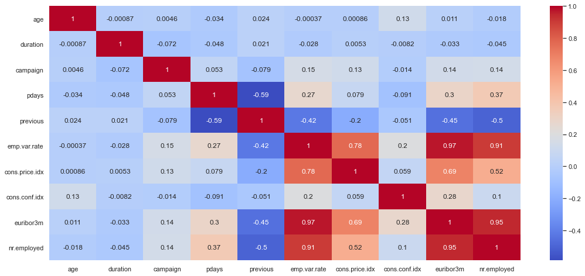

```python
# Student's Answer:
sns.set(rc={'figure.figsize':(18,8)})
sns.heatmap(dataset.corr(),cmap='coolwarm',annot=True)
plt.show()
```

### 8. Create some simple and quick plots with all the feature (hint: `pairplot()`)

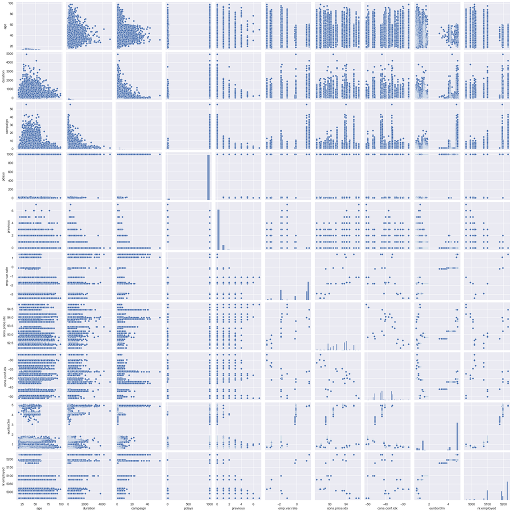

```python
# Student's Answer:
sns.pairplot(dataset)
plt.show()
```

### 9. Create additional plots which could discover and support the key data findings for Part 1

```python
dataset.info()
```

```
<class 'pandas.core.frame.DataFrame'>
RangeIndex: 41188 entries, 0 to 41187
Data columns (total 21 columns):
 #   Column          Non-Null Count  Dtype
---  ------          --------------  -----
 0   age             41188 non-null  int64
 1   job             41188 non-null  object
 2   marital         41188 non-null  object
 3   education       41188 non-null  object
 4   default         41188 non-null  object
 5   housing         41188 non-null  object
 6   loan            41188 non-null  object
 7   contact         41188 non-null  object
 8   month           41188 non-null  object
 9   day_of_week     41188 non-null  object
 10  duration        41188 non-null  int64
 11  campaign        41188 non-null  int64
 12  pdays           41188 non-null  int64
 13  previous        41188 non-null  int64
 14  poutcome        41188 non-null  object
 15  emp.var.rate    41188 non-null  float64
 16  cons.price.idx  41188 non-null  float64
 17  cons.conf.idx   41188 non-null  float64
 18  euribor3m       41188 non-null  float64
 19  nr.employed     41188 non-null  float64
 20  y               41188 non-null  object
dtypes: float64(5), int64(5), object(11)
memory usage: 6.6+ MB
```

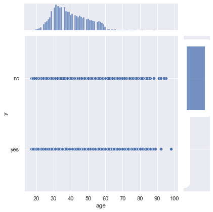

```python
sns.jointplot(x='age',y='y',data=dataset,kind='scatter')
plt.show()
```

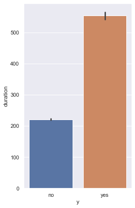

```python
sns.set(rc={'figure.figsize':(4,7)})
sns.barplot(x='y',y='duration',data=dataset)
plt.show()
```

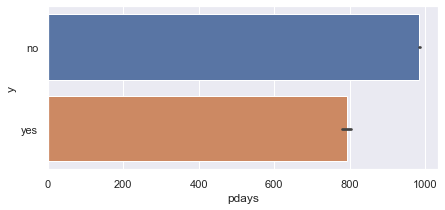

```python
sns.set(rc={'figure.figsize':(7,3)})
sns.barplot(x='pdays',y='y',data=dataset)
plt.show()
```

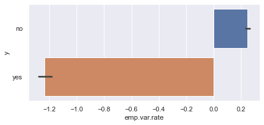

```python
sns.set(rc={'figure.figsize':(7,3)})
sns.barplot(x='emp.var.rate',y='y',data=dataset)
plt.show()
```

## Part 2 - Classifcation and Summary Report

### Review dataset for modeling relevance

### 1. Split dataset into train and test

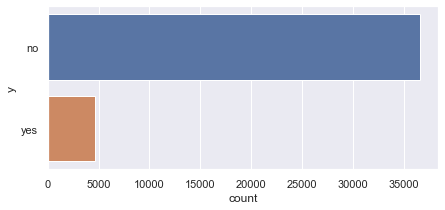

```python
# Check the need to split your data using stratified random sampling
sns.countplot(y='y', data=dataset)
plt.show()
```

```python
dataset
```

|  | age | job | marital | education | default | housing | loan | contact | month | day_of_week | ... | campaign | pdays | previous | poutcome | emp.var.rate | cons.price.idx | cons.conf.idx | euribor3m | nr.employed | y |
| --- | --- | --- | --- | --- | --- | --- | --- | --- | --- | --- | --- | --- | --- | --- | --- | --- | --- | --- | --- | --- | --- |
| 0 | 56 | housemaid | married | basic.4y | no | no | no | telephone | may | mon | ... | 1 | 999 | 0 | nonexistent | 1.1 | 93.994 | -36.4 | 4.857 | 5191.0 | no |
| 1 | 57 | services | married | high.school | unknown | no | no | telephone | may | mon | ... | 1 | 999 | 0 | nonexistent | 1.1 | 93.994 | -36.4 | 4.857 | 5191.0 | no |
| 2 | 37 | services | married | high.school | no | yes | no | telephone | may | mon | ... | 1 | 999 | 0 | nonexistent | 1.1 | 93.994 | -36.4 | 4.857 | 5191.0 | no |
| 3 | 40 | admin. | married | basic.6y | no | no | no | telephone | may | mon | ... | 1 | 999 | 0 | nonexistent | 1.1 | 93.994 | -36.4 | 4.857 | 5191.0 | no |
| 4 | 56 | services | married | high.school | no | no | yes | telephone | may | mon | ... | 1 | 999 | 0 | nonexistent | 1.1 | 93.994 | -36.4 | 4.857 | 5191.0 | no |
| ... | ... | ... | ... | ... | ... | ... | ... | ... | ... | ... | ... | ... | ... | ... | ... | ... | ... | ... | ... | ... | ... |
| 41183 | 73 | retired | married | professional.course | no | yes | no | cellular | nov | fri | ... | 1 | 999 | 0 | nonexistent | -1.1 | 94.767 | -50.8 | 1.028 | 4963.6 | yes |
| 41184 | 46 | blue-collar | married | professional.course | no | no | no | cellular | nov | fri | ... | 1 | 999 | 0 | nonexistent | -1.1 | 94.767 | -50.8 | 1.028 | 4963.6 | no |
| 41185 | 56 | retired | married | university.degree | no | yes | no | cellular | nov | fri | ... | 2 | 999 | 0 | nonexistent | -1.1 | 94.767 | -50.8 | 1.028 | 4963.6 | no |
| 41186 | 44 | technician | married | professional.course | no | no | no | cellular | nov | fri | ... | 1 | 999 | 0 | nonexistent | -1.1 | 94.767 | -50.8 | 1.028 | 4963.6 | yes |
| 41187 | 74 | retired | married | professional.course | no | yes | no | cellular | nov | fri | ... | 3 | 999 | 1 | failure | -1.1 | 94.767 | -50.8 | 1.028 | 4963.6 | no |

41188 rows × 21 columns

```python
data = dataset[['loan','job','marital','housing','default','contact','education','poutcome','emp.var.rate','cons.price.idx','cons.conf.idx','euribor3m','nr.employed','y']]
data.head(3)
```

|  | loan | job | marital | housing | default | contact | education | poutcome | emp.var.rate | cons.price.idx | cons.conf.idx | euribor3m | nr.employed | y |
| --- | --- | --- | --- | --- | --- | --- | --- | --- | --- | --- | --- | --- | --- | --- |
| 0 | no | housemaid | married | no | no | telephone | basic.4y | nonexistent | 1.1 | 93.994 | -36.4 | 4.857 | 5191.0 | no |
| 1 | no | services | married | no | unknown | telephone | high.school | nonexistent | 1.1 | 93.994 | -36.4 | 4.857 | 5191.0 | no |
| 2 | no | services | married | yes | no | telephone | high.school | nonexistent | 1.1 | 93.994 | -36.4 | 4.857 | 5191.0 | no |

```python
data = pd.get_dummies(data,drop_first= True)
data
```

|  | emp.var.rate | cons.price.idx | cons.conf.idx | euribor3m | nr.employed | loan_unknown | loan_yes | job_blue-collar | job_entrepreneur | job_housemaid | ... | education_basic.6y | education_basic.9y | education_high.school | education_illiterate | education_professional.course | education_university.degree | education_unknown | poutcome_nonexistent | poutcome_success | y_yes |
| --- | --- | --- | --- | --- | --- | --- | --- | --- | --- | --- | --- | --- | --- | --- | --- | --- | --- | --- | --- | --- | --- |
| 0 | 1.1 | 93.994 | -36.4 | 4.857 | 5191.0 | 0 | 0 | 0 | 0 | 1 | ... | 0 | 0 | 0 | 0 | 0 | 0 | 0 | 1 | 0 | 0 |
| 1 | 1.1 | 93.994 | -36.4 | 4.857 | 5191.0 | 0 | 0 | 0 | 0 | 0 | ... | 0 | 0 | 1 | 0 | 0 | 0 | 0 | 1 | 0 | 0 |
| 2 | 1.1 | 93.994 | -36.4 | 4.857 | 5191.0 | 0 | 0 | 0 | 0 | 0 | ... | 0 | 0 | 1 | 0 | 0 | 0 | 0 | 1 | 0 | 0 |
| 3 | 1.1 | 93.994 | -36.4 | 4.857 | 5191.0 | 0 | 0 | 0 | 0 | 0 | ... | 1 | 0 | 0 | 0 | 0 | 0 | 0 | 1 | 0 | 0 |
| 4 | 1.1 | 93.994 | -36.4 | 4.857 | 5191.0 | 0 | 1 | 0 | 0 | 0 | ... | 0 | 0 | 1 | 0 | 0 | 0 | 0 | 1 | 0 | 0 |
| ... | ... | ... | ... | ... | ... | ... | ... | ... | ... | ... | ... | ... | ... | ... | ... | ... | ... | ... | ... | ... | ... |
| 41183 | -1.1 | 94.767 | -50.8 | 1.028 | 4963.6 | 0 | 0 | 0 | 0 | 0 | ... | 0 | 0 | 0 | 0 | 1 | 0 | 0 | 1 | 0 | 1 |
| 41184 | -1.1 | 94.767 | -50.8 | 1.028 | 4963.6 | 0 | 0 | 1 | 0 | 0 | ... | 0 | 0 | 0 | 0 | 1 | 0 | 0 | 1 | 0 | 0 |
| 41185 | -1.1 | 94.767 | -50.8 | 1.028 | 4963.6 | 0 | 0 | 0 | 0 | 0 | ... | 0 | 0 | 0 | 0 | 0 | 1 | 0 | 1 | 0 | 0 |
| 41186 | -1.1 | 94.767 | -50.8 | 1.028 | 4963.6 | 0 | 0 | 0 | 0 | 0 | ... | 0 | 0 | 0 | 0 | 1 | 0 | 0 | 1 | 0 | 1 |
| 41187 | -1.1 | 94.767 | -50.8 | 1.028 | 4963.6 | 0 | 0 | 0 | 0 | 0 | ... | 0 | 0 | 0 | 0 | 1 | 0 | 0 | 0 | 0 | 0 |

41188 rows × 36 columns

```python
X = data.iloc[:, :-1].values
y = data.iloc[:, -1].values
```

```python
split_list = train_test_split(X, y, test_size=0.2, random_state=1,stratify=dataset.y)

# Unpack split_list into four new objects and print their shapes
input_train, input_test, target_train, target_test = split_list
for item in [input_train, input_test, target_train, target_test]:
    print(item.shape)
```

```
(32950, 35)
(8238, 35)
(32950,)
(8238,)
```

```python
pipelines = {
    'k-nearest NeighborClassifier' : make_pipeline(StandardScaler(), KNeighborsClassifier(n_neighbors = 10, metric = 'minkowski', p = 2)),
    'logistic Regression' : make_pipeline(StandardScaler(), LogisticRegression(random_state = 0)),
    'Descision TreeClassifier' : make_pipeline(StandardScaler(), DecisionTreeClassifier(criterion = 'entropy', random_state = 0)),
    'Random ForestClassifier' : make_pipeline(StandardScaler(), RandomForestClassifier(n_estimators = 10, criterion = 'entropy', random_state = 0)),
    'Support VectorClassifer' : make_pipeline(StandardScaler(), SVC(kernel = 'linear', random_state = 0))
}
```

```python
for key, value in pipelines.items():
    print(key, type(value))
```

```
k-nearest NeighborClassifier <class 'sklearn.pipeline.Pipeline'>
logistic Regression <class 'sklearn.pipeline.Pipeline'>
Descision TreeClassifier <class 'sklearn.pipeline.Pipeline'>
Random ForestClassifier <class 'sklearn.pipeline.Pipeline'>
Support VectorClassifer <class 'sklearn.pipeline.Pipeline'>
```

```python
models ={}

for key in pipelines.keys():
    models[key] = pipelines[key].fit(input_train, target_train)
    print(key, 'is trained and tuned')
```

```
k-nearest NeighborClassifier is trained and tuned
logistic Regression is trained and tuned
Descision TreeClassifier is trained and tuned
Random ForestClassifier is trained and tuned
Support VectorClassifer is trained and tuned
```

```python
for key in models.keys():
    pred = models[key].predict(input_test)
    print(key)
    print(confusion_matrix(target_test, pred))
    print('  ')
```

```
k-nearest NeighborClassifier
[[7201  109]
 [ 737  191]]

logistic Regression
[[7209  101]
 [ 727  201]]

Descision TreeClassifier
[[6847  463]
 [ 644  284]]

Random ForestClassifier
[[7005  305]
 [ 676  252]]

Support VectorClassifer
[[7221   89]
 [ 744  184]]
```

### 3. Cross-Validation

```python
for key in models.keys():
    print(key)
    accuracies = cross_val_score(estimator = models[key], X = input_train, y = target_train, cv = 5)
    print("Accuracy: {:.2f} %".format(accuracies.mean()*100))
    print("Standard Deviation: {:.2f} %".format(accuracies.std()*100))
    print(' ')
```

```
k-nearest NeighborClassifier
Accuracy: 89.56 %
Standard Deviation: 0.17 %

logistic Regression
Accuracy: 89.82 %
Standard Deviation: 0.15 %

Descision TreeClassifier
Accuracy: 86.63 %
Standard Deviation: 0.56 %

Random ForestClassifier
Accuracy: 88.16 %
Standard Deviation: 0.47 %

Support VectorClassifer
Accuracy: 89.71 %
Standard Deviation: 0.13 %
```

### 4. Model Selection & Classification Report

```python
for key in models.keys():
    print(key)
    print(classification_report(target_test, models[key].predict(input_test)))
    print(confusion_matrix(target_test, models[key].predict(input_test)))
    print('    ')
```

```
k-nearest NeighborClassifier
              precision    recall  f1-score   support

           0       0.91      0.99      0.94      7310
           1       0.64      0.21      0.31       928

    accuracy                           0.90      8238
   macro avg       0.77      0.60      0.63      8238
weighted avg       0.88      0.90      0.87      8238

[[7201  109]
 [ 737  191]]

logistic Regression
              precision    recall  f1-score   support

           0       0.91      0.99      0.95      7310
           1       0.67      0.22      0.33       928

    accuracy                           0.90      8238
   macro avg       0.79      0.60      0.64      8238
weighted avg       0.88      0.90      0.88      8238

[[7209  101]
 [ 727  201]]

Descision TreeClassifier
              precision    recall  f1-score   support

           0       0.91      0.94      0.93      7310
           1       0.38      0.31      0.34       928

    accuracy                           0.87      8238
   macro avg       0.65      0.62      0.63      8238
weighted avg       0.85      0.87      0.86      8238

[[6847  463]
 [ 644  284]]

Random ForestClassifier
```

[output cut: 9 more lines]

```
[[7005  305]
 [ 676  252]]

Support VectorClassifer
              precision    recall  f1-score   support

           0       0.91      0.99      0.95      7310
           1       0.67      0.20      0.31       928

    accuracy                           0.90      8238
   macro avg       0.79      0.59      0.63      8238
weighted avg       0.88      0.90      0.87      8238

[[7221   89]
 [ 744  184]]
```